# Lecture: K Nearest Neighbors

2023-01-10

## KNN Demonstration

```r
patients <- read.csv("breast-cancer.csv") %>% clean_names() %>% mutate(class = factor(class))
glimpse(patients)
```

```
## Rows: 683
## Columns: 11
## $ id                          <int> 1000025, 1002945, 1015425, 1016277, 101702…
## $ clump_thickness             <int> 5, 5, 3, 6, 4, 8, 1, 2, 2, 4, 1, 2, 5, 1, …
## $ uniformity_of_cell_size     <int> 1, 4, 1, 8, 1, 10, 1, 1, 1, 2, 1, 1, 3, 1,…
## $ uniformity_of_cell_shape    <int> 1, 4, 1, 8, 1, 10, 1, 2, 1, 1, 1, 1, 3, 1,…
## $ marginal_adhesion           <int> 1, 5, 1, 1, 3, 8, 1, 1, 1, 1, 1, 1, 3, 1, …
## $ single_epithelial_cell_size <int> 2, 7, 2, 3, 2, 7, 2, 2, 2, 2, 1, 2, 2, 2, …
## $ bare_nuclei                 <int> 1, 10, 2, 4, 1, 10, 10, 1, 1, 1, 1, 1, 3, …
## $ bland_chromatin             <int> 3, 3, 3, 3, 3, 9, 3, 3, 1, 2, 3, 2, 4, 3, …
## $ normal_nucleoli             <int> 1, 2, 1, 7, 1, 7, 1, 1, 1, 1, 1, 1, 4, 1, …
## $ mitoses                     <int> 1, 1, 1, 1, 1, 1, 1, 1, 5, 1, 1, 1, 1, 1, …
## $ class                       <fct> 0, 0, 0, 0, 0, 1, 0, 0, 0, 0, 0, 0, 1, 0, …
```

```r
patients %>% group_by(class) %>% summarise(n=n())
```

```
## # A tibble: 2 × 2
##   class     n
##   <fct> <int>
## 1 0       444
## 2 1       239
```

```r
skim(patients)
```

Data summary

| Name | patients |
| --- | --- |
| Number of rows | 683 |
| Number of columns | 11 |
| _______________________ |  |
| Column type frequency: |  |
| factor | 1 |
| numeric | 10 |
| ________________________ |  |
| Group variables | None |

**Variable type: factor**

| skim_variable | n_missing | complete_rate | ordered | n_unique | top_counts |
| --- | --- | --- | --- | --- | --- |
| class | 0 | 1 | FALSE | 2 | 0: 444, 1: 239 |

**Variable type: numeric**

| skim_variable | n_missing | complete_rate | mean | sd | p0 | p25 | p50 | p75 | p100 | hist |
| --- | --- | --- | --- | --- | --- | --- | --- | --- | --- | --- |
| id | 0 | 1 | 1076720.23 | 620644.05 | 63375 | 877617 | 1171795 | 1238705 | 13454352 | ▇▁▁▁▁ |
| clump_thickness | 0 | 1 | 4.44 | 2.82 | 1 | 2 | 4 | 6 | 10 | ▇▇▇▃▃ |
| uniformity_of_cell_size | 0 | 1 | 3.15 | 3.07 | 1 | 1 | 1 | 5 | 10 | ▇▂▁▁▂ |
| uniformity_of_cell_shape | 0 | 1 | 3.22 | 2.99 | 1 | 1 | 1 | 5 | 10 | ▇▂▁▁▁ |
| marginal_adhesion | 0 | 1 | 2.83 | 2.86 | 1 | 1 | 1 | 4 | 10 | ▇▂▁▁▁ |
| single_epithelial_cell_size | 0 | 1 | 3.23 | 2.22 | 1 | 2 | 2 | 4 | 10 | ▇▂▂▁▁ |
| bare_nuclei | 0 | 1 | 3.54 | 3.64 | 1 | 1 | 1 | 6 | 10 | ▇▁▁▁▂ |
| bland_chromatin | 0 | 1 | 3.45 | 2.45 | 1 | 2 | 3 | 5 | 10 | ▇▅▁▂▁ |
| normal_nucleoli | 0 | 1 | 2.87 | 3.05 | 1 | 1 | 1 | 4 | 10 | ▇▁▁▁▁ |
| mitoses | 0 | 1 | 1.60 | 1.73 | 1 | 1 | 1 | 1 | 10 | ▇▁▁▁▁ |

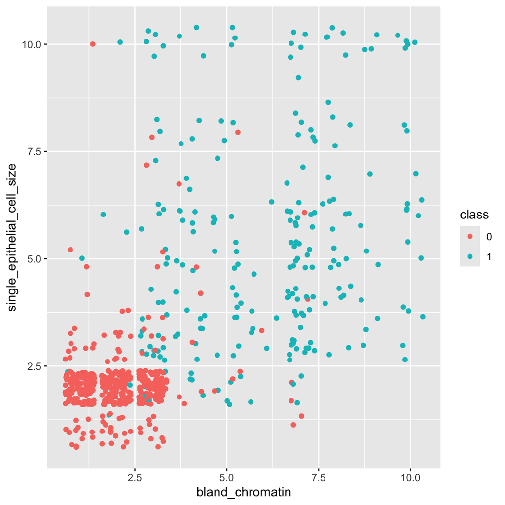

```r
ggplot(data=patients, aes(x=bland_chromatin, y=single_epithelial_cell_size, color=class)) +
  geom_point(position="jitter")
```

These two quantities look nicely separated, and could be useful for prediction! Let’s use them to create a `k` Nearest Neighbors Model.

## What does KNN do?

Suppose we are diagnosing a new patient, and we get readings on `bland_chromatin` and `single_epithelial_cell_size`, say 3 and 5, respectively.

```r
patients_split <- initial_split(patients, prop = 0.80, strata = class)
patients_train <- training(patients_split)
patients_test <- testing(patients_split)
```

```r
patients_train %>%
  mutate(
    dist = sqrt((bland_chromatin-3)^2+(single_epithelial_cell_size-5)^2)
    ) %>%
  slice_min(dist, n=5, with_ties=TRUE) # There are a bunch of ties!
```

```
##        id clump_thickness uniformity_of_cell_size uniformity_of_cell_shape
## 1  242970               5                       7                        7
## 2  718641               1                       1                        1
## 3 1116132               6                       3                        4
## 4 1171845               8                       6                        4
## 5  832226               3                       4                        4
##   marginal_adhesion single_epithelial_cell_size bare_nuclei bland_chromatin
## 1                 1                           5           8               3
## 2                 1                           5           1               3
## 3                 1                           5           2               3
## 4                 3                           5           9               3
## 5                10                           5           1               3
##   normal_nucleoli mitoses class dist
## 1               4       1     0    0
## 2               1       1     0    0
## 3               9       1     1    0
## 4               1       1     1    0
## 5               3       1     1    0
```

What class should we predict here? What if we change the number of neighbors? What if we change the point?

## Building a KNN Model

Specify the model:

```r
knn_model <- nearest_neighbor(weight_func = "rectangular", neighbors = 3) %>%
  set_engine("kknn") %>%
  set_mode("classification")
```

Fit the model to the training data. You will need to install the `kknn` package.

```r
knn_fit <- knn_model %>%
  fit(class ~ bland_chromatin + single_epithelial_cell_size, data = patients_train)
```

Evaluate the model on the test set (recall that we may also use `augment` here)

```r
patients_pred <- knn_fit %>%
  augment(new_data=patients_test)
```

```r
# Some performance metrics for classification
conf_mat(patients_pred, truth = class, estimate = .pred_class)
```

```
##           Truth
## Prediction  0  1
##          0 85  9
##          1  4 39
```

```r
my_metrics <- metric_set(sens, spec, accuracy)
my_metrics(patients_pred, truth = class, estimate = .pred_class)
```

```
## # A tibble: 3 × 3
##   .metric  .estimator .estimate
##   <chr>    <chr>          <dbl>
## 1 sens     binary         0.955
## 2 spec     binary         0.812
## 3 accuracy binary         0.905
```

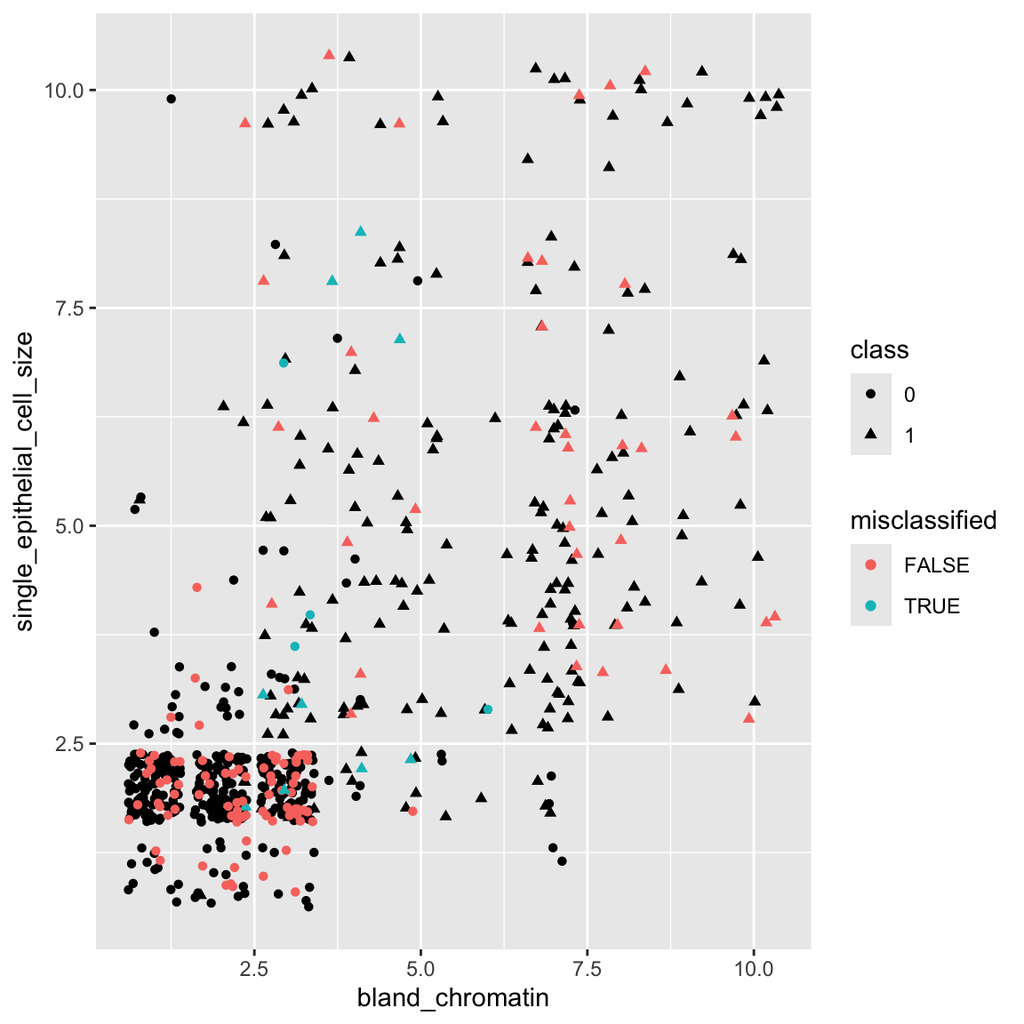

```r
patients_pred <- patients_pred %>% mutate(misclassified = if_else(class != .pred_class, TRUE, FALSE))
ggplot(data=patients_pred, aes(x=bland_chromatin, y=single_epithelial_cell_size)) +
  geom_point(
    data=patients_train,
    aes(x=bland_chromatin, y=single_epithelial_cell_size, shape=class),
    position="jitter")+
  geom_point(
    aes(color=misclassified, shape=class),
    position="jitter")
```

```r
patients_pred %>% filter(class != .pred_class) %>% head()
```

```
## # A tibble: 6 × 15
##   .pred_class .pred_0 .pred_1      id clump_thickness uniformity_of_cell_size
##   <fct>         <dbl>   <dbl>   <int>           <int>                   <int>
## 1 1             0.333   0.667 1002945               5                       4
## 2 0             0.667   0.333 1041801               5                       3
## 3 0             0.667   0.333 1044572               8                       7
## 4 0             1       0     1108370               9                       5
## 5 0             1       0     1112209               8                      10
## 6 0             1       0     1169049               7                       3
## # ℹ 9 more variables: uniformity_of_cell_shape <int>, marginal_adhesion <int>,
## #   single_epithelial_cell_size <int>, bare_nuclei <int>,
## #   bland_chromatin <int>, normal_nucleoli <int>, mitoses <int>, class <fct>,
## #   misclassified <lgl>
```

# How many neighbors should we use?

```r
knn_fit <- knn_model %>%
  # change this to whatever you want and compare with your neighbors
  set_args(neighbors=5) %>%
  # Can we try fitting on all the predictors?
  fit(class ~ . -id, data = patients_train)

patients_pred <- augment(knn_fit, new_data=patients_test)

#conf_mat(patients_pred, truth = class, estimate = .pred_class)
my_metrics(patients_pred, truth = class, estimate = .pred_class)
```

```
## # A tibble: 3 × 3
##   .metric  .estimator .estimate
##   <chr>    <chr>          <dbl>
## 1 sens     binary         0.978
## 2 spec     binary         0.979
## 3 accuracy binary         0.978
```

# Weighted KNN

Should all the nearest neighbors get an equal vote? Shouldn’t the closest neighbors have a bigger say? This information can be incorporated using weight functions, which give more weight to closer observations and less to ones further away. See [this paper](https://epub.ub.uni-muenchen.de/1769/1/paper_399.pdf) for more details.

```r
knn_recipe <- recipe(class ~ ., data=patients_train) %>%
  update_role(id, new_role="id") %>%
  step_normalize(all_numeric_predictors())

knn_model <- nearest_neighbor(neighbors=5, weight_func="gaussian") %>% # What are the default arguments?
  set_engine("kknn") %>%
  set_mode("classification")

knn_wf <- workflow() %>%
  add_recipe(knn_recipe) %>%
  add_model(knn_model)

knn_fit <- knn_wf %>% fit(data = patients_train)

patients_pred <- augment(knn_fit, new_data=patients_test)

conf_mat(patients_pred, truth = class, estimate = .pred_class)
```

```
##           Truth
## Prediction  0  1
##          0 87  1
##          1  2 47
```

```r
my_metrics(patients_pred, truth = class, estimate = .pred_class)
```

```
## # A tibble: 3 × 3
##   .metric  .estimator .estimate
##   <chr>    <chr>          <dbl>
## 1 sens     binary         0.978
## 2 spec     binary         0.979
## 3 accuracy binary         0.978
```

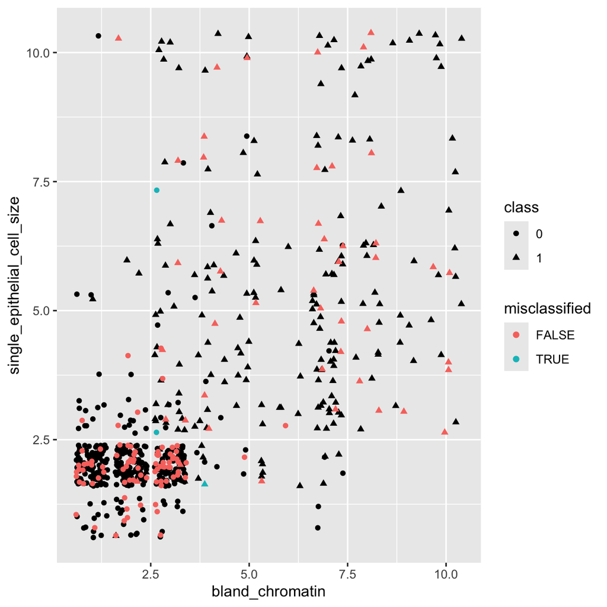

```r
# make a column that shows whether or not patient was misclassified
patients_pred <- patients_pred %>% mutate(misclassified = if_else(class != .pred_class, TRUE, FALSE))

# where are the misclassified patients?
ggplot(data=patients_pred, aes(x=bland_chromatin, y=single_epithelial_cell_size))+
  geom_point(
    data=patients_train,
    aes(x=bland_chromatin, y=single_epithelial_cell_size, shape=class),
    position="jitter") +
  geom_point(
    aes(color=misclassified, shape=class),
    position="jitter")
```

# Resampling

## V-fold Cross-validation

The function `vfold_cv` is used to create the cross-validation folds. What are the default arguments?

```r
patients_folds <- vfold_cv(patients_train, v = 10)
# to actually return a particular fold
#patients_folds$splits[[4]] %>% analysis()
#patients_folds$splits[[4]] %>% assessment()
```

## Repeated V-fold Cross-validation

We can also set up the folds to repeat many times. How many estimates do we have now?

```r
patients_folds <- vfold_cv(patients_train, v = 10, repeats = 5)
# to actually return a particular fold:
# patients_folds$splits[[1]] %>% analysis()
# patients_folds$splits[[1]] %>% assessment()
```

## Fitting the resamples

Now our workflow object can fit the model to each analysis set and compute metrics on each assessment set. You can also pass `fit_resamples` a metric set, otherwise it will automatically choose.

```r
# This might take a while!
diab_res <- knn_wf %>% fit_resamples(resamples = patients_folds)
diab_res
```

```
## # Resampling results
## # 10-fold cross-validation repeated 5 times
## # A tibble: 50 × 5
##    splits           id      id2    .metrics         .notes
##    <list>           <chr>   <chr>  <list>           <list>
##  1 <split [491/55]> Repeat1 Fold01 <tibble [3 × 4]> <tibble [0 × 3]>
##  2 <split [491/55]> Repeat1 Fold02 <tibble [3 × 4]> <tibble [0 × 3]>
##  3 <split [491/55]> Repeat1 Fold03 <tibble [3 × 4]> <tibble [0 × 3]>
##  4 <split [491/55]> Repeat1 Fold04 <tibble [3 × 4]> <tibble [0 × 3]>
##  5 <split [491/55]> Repeat1 Fold05 <tibble [3 × 4]> <tibble [0 × 3]>
##  6 <split [491/55]> Repeat1 Fold06 <tibble [3 × 4]> <tibble [0 × 3]>
##  7 <split [492/54]> Repeat1 Fold07 <tibble [3 × 4]> <tibble [0 × 3]>
##  8 <split [492/54]> Repeat1 Fold08 <tibble [3 × 4]> <tibble [0 × 3]>
##  9 <split [492/54]> Repeat1 Fold09 <tibble [3 × 4]> <tibble [0 × 3]>
## 10 <split [492/54]> Repeat1 Fold10 <tibble [3 × 4]> <tibble [0 × 3]>
## # ℹ 40 more rows
```

```r
collect_metrics(diab_res)
```

```
## # A tibble: 3 × 6
##   .metric     .estimator   mean     n std_err .config
##   <chr>       <chr>       <dbl> <int>   <dbl> <chr>
## 1 accuracy    binary     0.967     50 0.00392 Preprocessor1_Model1
## 2 brier_class binary     0.0267    50 0.00253 Preprocessor1_Model1
## 3 roc_auc     binary     0.989     50 0.00217 Preprocessor1_Model1
```

# Tuning hyperparameters

Parameters that we want to mark for tuning can take the `tune()` tag as an argument.

(Do you remember what `dist_power` is?)

```r
knn_model <- nearest_neighbor(neighbors = tune(), dist_power = tune()) %>%
  set_engine("kknn") %>%
  set_mode("classification")

knn_wf <- workflow() %>%
  add_recipe(knn_recipe) %>%
  add_model(knn_model)
```

We can take a look at the default parameter sets below:

```r
knn_param <- knn_wf %>% extract_parameter_set_dials()
knn_param %>% extract_parameter_dials("neighbors")
```

```
## # Nearest Neighbors (quantitative)
## Range: [1, 15]
```

```r
knn_param %>% extract_parameter_dials("dist_power")
```

```
## Minkowski Distance Order (quantitative)
## Range: [0.1, 2]
```

In our example, we said we were interested in dist powers between 1 and 2, and in 3, 5, 7, or 9 nearest neighbors. Here are two ways to create a regular grid like this:

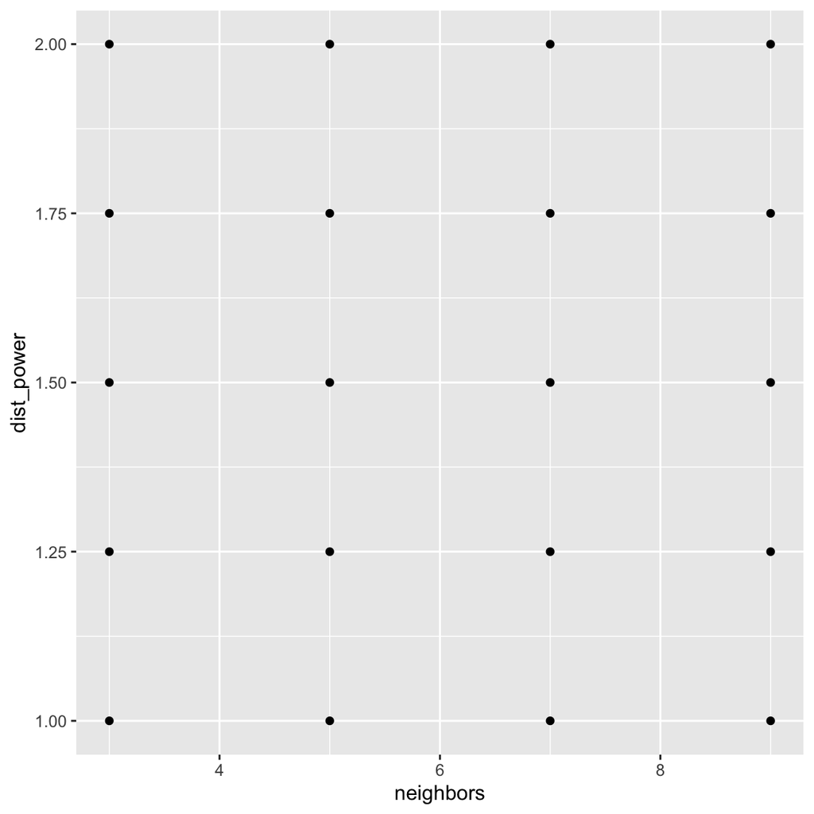

```r
# Way 1: Using the crossing function
# Creates a lot of combinations
my_grid <- crossing(
  neighbors = c(3, 5, 7, 9),
  dist_power = c(1, 1.25, 1.5, 1.75, 2)
  )

ggplot(my_grid, aes(neighbors, dist_power)) + geom_point()
```

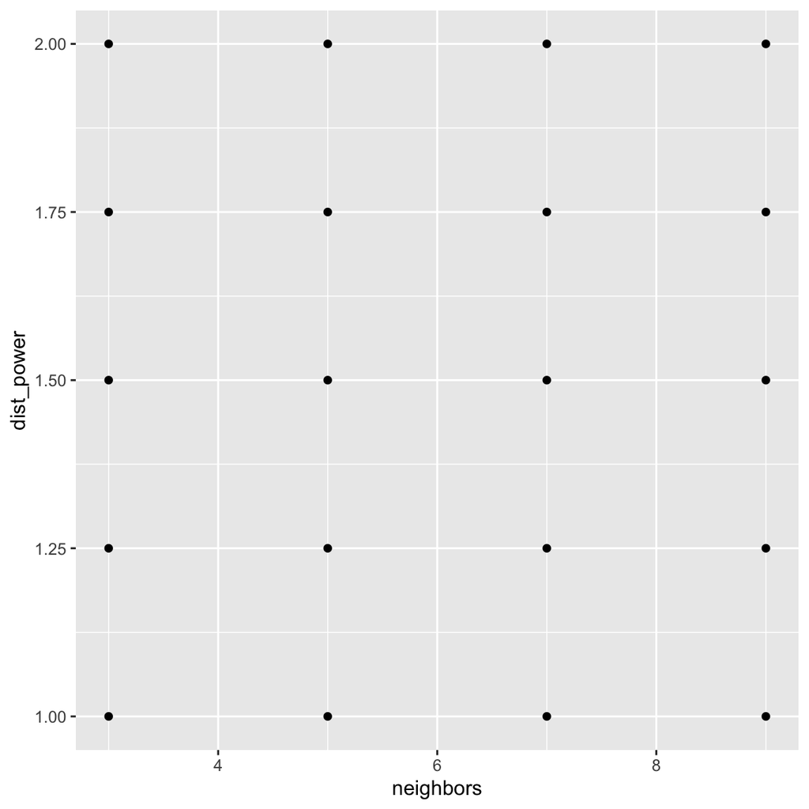

```r
# Way 2: Using the grid_regular function
knn_param <- knn_param %>% update(
  neighbors = neighbors(c(3,9)),
  dist_power = dist_power(c(1,2))
)

my_grid <- grid_regular(
  # the parameter set:
  knn_param,
  # how many divisions to make at each level. Could also be an integer to give the same number of levels for each parameter
  levels = c(neighbors=4, dist_power=5)
  )

ggplot(my_grid, aes(neighbors, dist_power)) + geom_point()
```

We use the `tune_grid` function in a similar way to how we used `fit_resamples`.

```r
# Will take a while!
knn_tune <- knn_wf %>%
  tune_grid(
    patients_folds, # the CV set
    grid=my_grid, # the number of levels of each parameter
    metrics=metric_set(accuracy) # the metrics you'd like to compute
    )
```

The book lists a bunch of ways to take a look at the different parameter combinations using plots! Here we’ll just use the `show_best()` function to get a look at the best performing combinations. “Best” is quantified according to the specified metric.

```r
knn_tune %>% show_best(n=20)
```

```
## # A tibble: 20 × 8
##    neighbors dist_power .metric  .estimator  mean     n std_err .config
##        <int>      <dbl> <chr>    <chr>      <dbl> <int>   <dbl> <chr>
##  1         9       1    accuracy binary     0.971    50 0.00331 Preprocessor1_M…
##  2         7       1    accuracy binary     0.971    50 0.00348 Preprocessor1_M…
##  3         5       1    accuracy binary     0.970    50 0.00346 Preprocessor1_M…
##  4         5       1.5  accuracy binary     0.968    50 0.00351 Preprocessor1_M…
##  5         9       1.25 accuracy binary     0.968    50 0.00373 Preprocessor1_M…
##  6         5       1.75 accuracy binary     0.967    50 0.00383 Preprocessor1_M…
##  7         7       1.25 accuracy binary     0.967    50 0.00390 Preprocessor1_M…
##  8         7       1.75 accuracy binary     0.967    50 0.00386 Preprocessor1_M…
##  9         7       1.5  accuracy binary     0.967    50 0.00382 Preprocessor1_M…
## 10         9       1.75 accuracy binary     0.967    50 0.00385 Preprocessor1_M…
## 11         5       1.25 accuracy binary     0.967    50 0.00385 Preprocessor1_M…
## 12         3       1    accuracy binary     0.966    50 0.00338 Preprocessor1_M…
## 13         5       2    accuracy binary     0.966    50 0.00386 Preprocessor1_M…
## 14         7       2    accuracy binary     0.966    50 0.00386 Preprocessor1_M…
## 15         9       2    accuracy binary     0.966    50 0.00386 Preprocessor1_M…
## 16         9       1.5  accuracy binary     0.966    50 0.00391 Preprocessor1_M…
## 17         3       1.25 accuracy binary     0.961    50 0.00389 Preprocessor1_M…
## 18         3       1.75 accuracy binary     0.959    50 0.00419 Preprocessor1_M…
## 19         3       1.5  accuracy binary     0.958    50 0.00411 Preprocessor1_M…
## 20         3       2    accuracy binary     0.957    50 0.00452 Preprocessor1_M…
```

Now that we have a best model, we can now update our workflow and fit it to the training set. We can use `select_*` to get the best performing parameter set:

```r
select_best(knn_tune, metric="accuracy")
```

```
## # A tibble: 1 × 3
##   neighbors dist_power .config
##       <int>      <dbl> <chr>
## 1         9          1 Preprocessor1_Model04
```

```r
#select_by_one_std_err(knn_tune, metric="accuracy", desc(neighbors))
```

```r
knn_wf <- knn_wf %>%
  finalize_workflow(
    parameters = select_best(knn_tune, metric="accuracy")
    # could also set the parameters "by hand" here, e.g.
    # parameters = c(neighbors = 9, dist_power=1)
  )

final_results <- knn_wf %>%
  fit(patients_train) %>%
  augment(new_data=patients_test)

my_metrics(final_results, truth=class, estimate=.pred_class, event_level="second")
```

```
## # A tibble: 3 × 3
##   .metric  .estimator .estimate
##   <chr>    <chr>          <dbl>
## 1 sens     binary         0.979
## 2 spec     binary         0.978
## 3 accuracy binary         0.978
```

Should we always choose the best performing model?

## Without specifying a grid:

```r
# Recreate the workflow, since we finalized it above
# once it is "finalized" there are no parameters to tune
knn_wf <- workflow() %>%
  add_recipe(knn_recipe) %>%
  add_model(knn_model)

knn_tune <- knn_wf %>%
  tune_grid(
    patients_folds, # the CV set
    grid=10, # the number of parameter combinations
    metrics=metric_set(accuracy) # the metrics you'd like to compute
    )
```

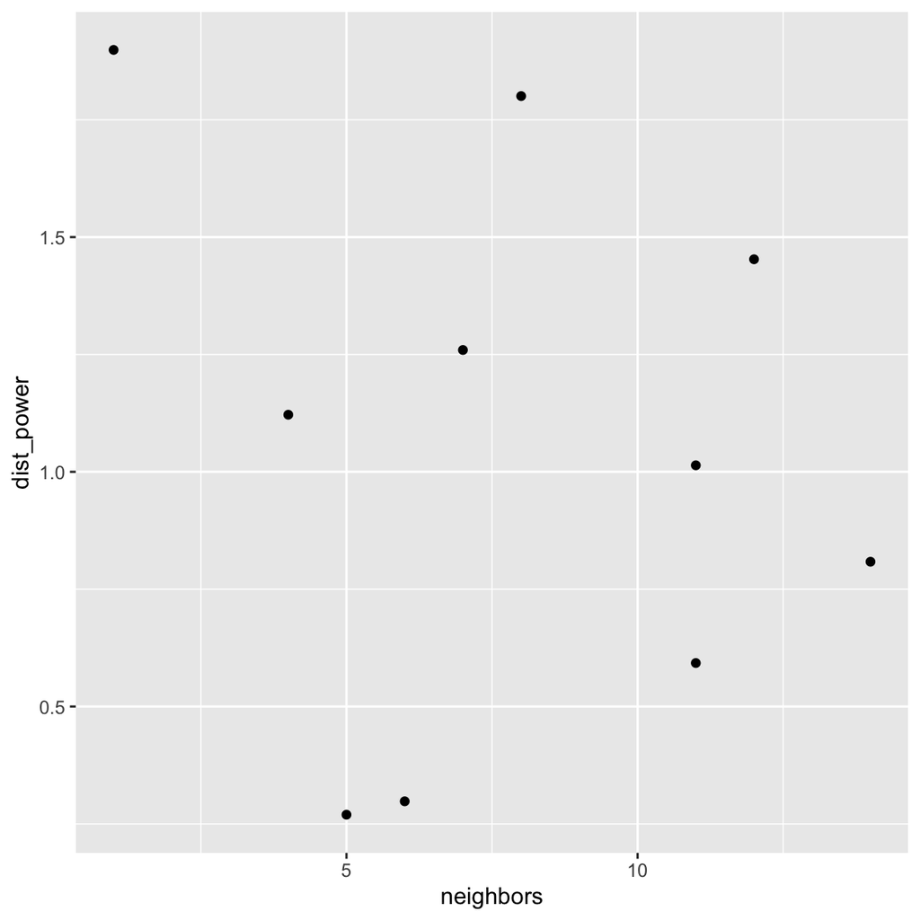

```r
knn_tune %>% show_best(n=10) %>%
  ggplot(aes(x=neighbors, y=dist_power)) +
  geom_point()
```

## Specifying other types of grids

Here are some other types of grids. Maximum entropy is the default for `tune_grid` I believe.

```r
my_grid <- grid_latin_hypercube(
  # the parameter set:
  knn_param,
  # how many points in the grid
  size = 13
  )
```

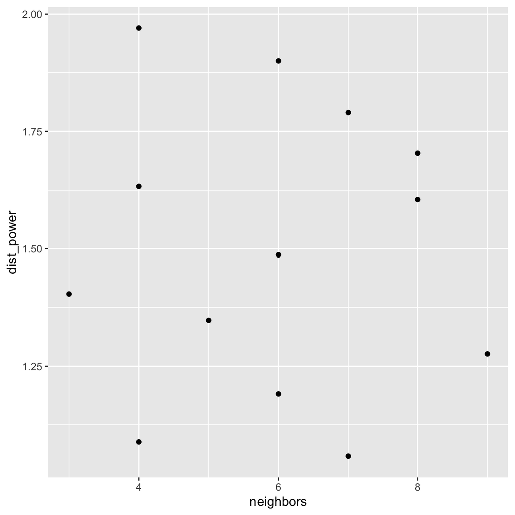

```r
ggplot(my_grid, aes(neighbors, dist_power)) + geom_point()
```

```r
my_grid <- grid_max_entropy(
  # the parameter set:
  knn_param,
  # how many points in the grid
  size = 13
  )
```

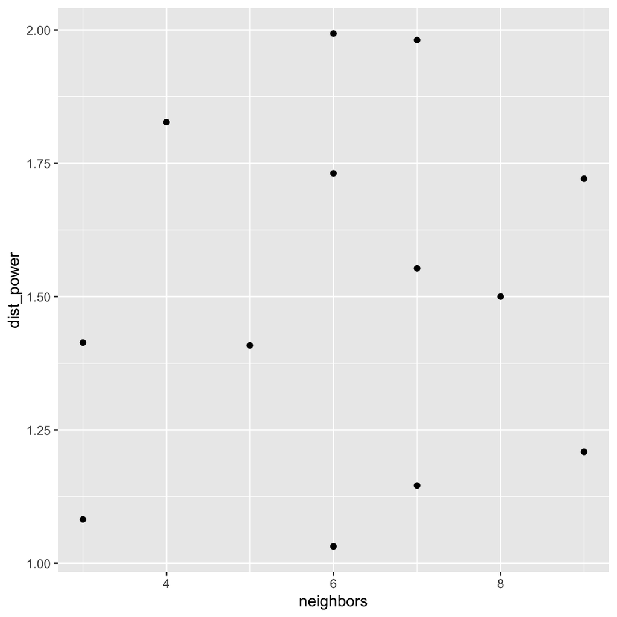

```r
ggplot(my_grid, aes(neighbors, dist_power)) + geom_point()
```